# 数据结构与算法(Python 语言描述)

## 1. 算法引入

算法是计算机处理信息的本质

五大特性：输入，输出，有穷性，确定性，可行性

如果 a+b+c=1000，且 a^2+b^=c^2（a,b,c 为自然数），如何求出所有a、b、c可能的组合?

```python
# 枚举法
# 思路  a = 0 b = 0 c = 0~1000

import time
start_time = time.time()

# 注意是三重循环
for a in range(0, 1001):
    for b in range(0, 1001):
        for c in range(0, 1001):
            if a+b+c == 1000 and a**2 + b**2 == c**2:
                print("a, b, c: %d, %d, %d" % (a, b, c))

end_time = time.time()
print("time: %f s" % (end_time - start_time))
print("complete!")

# T = 1000 * 1000 * 1000 * 2
```

```
a, b, c: 0, 500, 500
a, b, c: 200, 375, 425
a, b, c: 375, 200, 425
a, b, c: 500, 0, 500
time: 120.369356 s
complete!
```

```python
import time
start_time = time.time()

# 注意是三重循环
for a in range(0, 1001):
    for b in range(0, 1001):
        c = 1000 - a -b
        if a**2 + b**2 == c**2:
                print("a, b, c: %d, %d, %d" % (a, b, c))

end_time = time.time()
print("time: %f s" % (end_time - start_time))
print("complete!")
```

```
a, b, c: 0, 500, 500
a, b, c: 200, 375, 425
a, b, c: 375, 200, 425
a, b, c: 500, 0, 500
time: 0.912694 s
complete!
```

### 算法效率衡量

实现算法程序的执行时间反映出算法的效率，即算法的优劣

假定计算机执行每一个基本操作的时间是固定的，那么有多少个基本操作就代表会花费多少时间单位。 不同的机器环境确切的时间单位不同，但是对于算法进行多少个基本操作在规模数量级上是相同的。 时间复杂度，执行的基本运算数量。

对于算法的时间效率，可以用大O记法表示。

T(n) = n^3 *2 T(n) = n^3* 10 二者在同一数量级上，均是n^3 量级

“大O记法”：对于单调的整数函数f，如果存在一个整数函数g和实常数c>0，使得对于充分大的n总有f(n)<=c * g(n)，就说函数g是f的一个渐近函数（忽略常数），记为f(n)=O(g(n))。也就是说，在趋向无穷的极限意义下，函数f的增长速度受到函数g的约束，亦即函数f与函数g的特征相似。

时间复杂度：假设存在函数g，使得算法A处理规模为n的问题示例，所用时间为T(n)=O(g(n))，则称O(g(n))为算法A的渐近时间复杂度，简称时间复杂度，记为T(n)

对于算法进行特别具体的细致分析虽然很好，但在实践中的实际价值有限。对于算法的时间性质和空间性质，最重要的是其数量级和趋势，这些是分析算法效率的主要部分。而计量算法基本操作数量的规模函数中那些常量因子可以忽略不计。例如，可以认为3n^2和100n^2属于同一个量级，如果两个算法处理同样规模实例的代价分别为这两个函数，就认为它们的效率“差不多”，都为n^2级。

分析算法时，存在几种可能的考虑：

算法完成工作最少需要多少基本操作，即**最优时间复杂度**  
算法完成工作最多需要多少基本操作，即**最坏时间复杂度**  
算法完成工作平均需要多少基本操作，即**平均时间复杂度**

对于最优时间复杂度，其价值不大，因为它没有提供什么有用信息，其反映的只是最乐观最理想的情况，没有参考价值。

对于最坏时间复杂度，提供了一种保证，表明算法在此种程度的基本操作中一定能完成工作。

对于平均时间复杂度，是对算法的一个全面评价，因此它完整全面的反映了这个算法的性质。但另一方面，这种衡量并没有保证，不是每个计算都能在这个基本操作内完成。而且，对于平均情况的计算，也会因为应用算法的实例分布可能并不均匀而难以计算。

因此，我们主要**关注算法的最坏情况，亦即最坏时间复杂度**。

时间复杂度的几条基本计算规则:

1、基本操作，即只有常数项，认为其时间复杂度为O(1)  
2、顺序结构，时间复杂度按加法进行计算  
3、循环结构，时间复杂度按乘法进行计算  
4、分支结构，时间复杂度取最大值  
5、判断一个算法的效率时，往往只需要关注操作数量的最高次项，其它次要项和常数项可以忽略  
6、在没有特殊说明时，我们所分析的算法的时间复杂度都是指最坏时间复杂度

常见时间复杂度：

| 执行次数函数举例 | 阶 | 非正式术语 |
| --- | --- | --- |
| 12 | O(1) | 常数阶 |
| 2n + 3 | O(n) | 线性阶 |
| $ 3n^2+2n+1 $ | O($n^2$) | 平方阶 |
| $ 5\log_2n+20 $ | O(logn) | 对数阶 |
| $ 2n+3n\log_2n+19 $ | O(nlogn) | nlogn阶 |
| $ 6n^3+2n^2+3n+4 $ | O($n^3$) | 立方阶 |
| $ 2^n $ | O($2^n$) | 指数阶 |

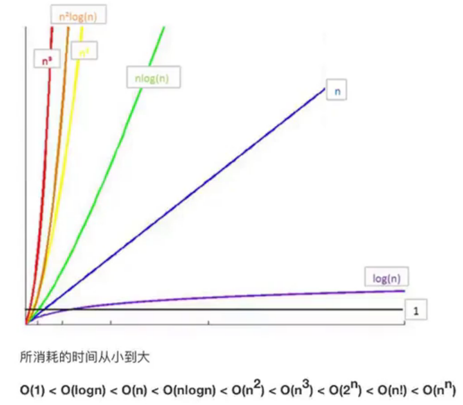

### Python内置类型性能分析

函数是对基本步骤的封装，不能看成一步。 引入timeit模块可以用来测试一小段Python代码的执行速度。 timeit里的Timer计时器类，需要传递3个参数。

class timeit.Timer(stmt='pass', setup='pass', timer=)  
Timer是测量小段代码执行速度的类。  
stmt参数是要测试的代码语句（statment）  
setup参数是运行代码时需要的设置  
timer参数是一个定时器函数，与平台有关。

timeit.Timer.timeit(number=1000000) Timer类中测试语句执行速度的对象方法。number参数是测试代码时的测试次数，默认为1000000次。方法返回执行代码的平均耗时，一个float类型的秒数。

注意，文件名不能与导入包重名。

```python
#!/usr/bin/env python
# -*- coding: utf-8 -*-
# @Author  : Henry

# python内置类型性能分析模块
import timeit
from timeit import Timer
```

### list的操作测试

```python
# Python2 range() 函数返回的是列表。 xrange() 创建迭代对象
# Python3 range() 函数返回的是一个可迭代对象（类型是对象），
# 而不是列表类型， 所以打印的时候不会打印列表。

# 加操作
li1 = [1, 2]
li2 = [23, 5]
li = li1 + li2

# 列表生成器
li = [i for i in range(1000)]

# 可迭代对象直接转换为列表
li = list(range(10000))

# 空列表追加
li = []
for i in range(10000):
    li.append(i)
```

```python
def test1():
    li = []
    for i in range(10000):
        li.append(i)
```

```python
def test2():
    li = []
    for i in range(10000):
        li = li + [i]
# 在List对象上操作
```

```python
def test2_1():
    li = []
    for i in range(10000):
        li += [i]
# += 魔法方法内部调用extend
```

```python
def test3():
    li = [i for i in range(10000)]
```

```python
def test4():
    li = list(range(10000))
```

```python
def test5():
    li = []
    for i in range(10000):
        li.extend([i])
```

```python
def test6():
    li = []
    for i in range(1000):
        li.insert(0, i)
```

```python
timer1 = Timer("test1()","from __main__ import test1")
print("append: ",timer1.timeit(number=1000), "seconds")
```

```
append:  0.830163819999143 seconds
```

```python
timer2 = Timer("test2()","from __main__ import test2")
print("+: ",timer2.timeit(number=1000), "seconds")
```

```
+:  148.88851439499922 seconds
```

```python
timer2_1 = Timer("test2_1()","from __main__ import test2_1")
print("+: ",timer2_1.timeit(number=1000), "seconds")
```

```
+:  0.619049566998001 seconds
```

```python
timer3 = Timer("test3()","from __main__ import test3")
print("[]: ",timer3.timeit(number=1000), "seconds")
```

```
[]:  0.35209578899957705 seconds
```

```python
timer4 = Timer("test4()","from __main__ import test4")
print("list function: ",timer4.timeit(number=1000), "seconds")
```

```
list function:  0.19331942600183538 seconds
```

```python
timer5 = Timer("test5()","from __main__ import test5")
print("extend function: ",timer5.timeit(number=1000), "seconds")
```

```
extend function:  1.2148926010013383 seconds
```

```python
timer6 = Timer("test6()","from __main__ import test6")
print("insert function: ",timer6.timeit(number=1000), "seconds")
```

```
insert function:  0.36234356700151693 seconds
```

### pop操作测试

```python
x = list(range(2000000))
pop_zero = Timer("x.pop(0)","from __main__ import x")
print("pop_zero ",pop_zero.timeit(number=1000), "seconds")
x = list(range(2000000))
pop_end = Timer("x.pop()","from __main__ import x")
print("pop_end ",pop_end.timeit(number=1000), "seconds")
```

```
pop_zero  2.8895222739993187 seconds
pop_end  8.407700079260394e-05 seconds
```

测试pop操作：从结果可以看出，pop最后一个元素的效率远远高于pop第一个元素

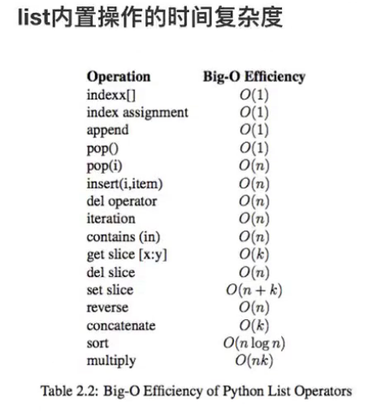

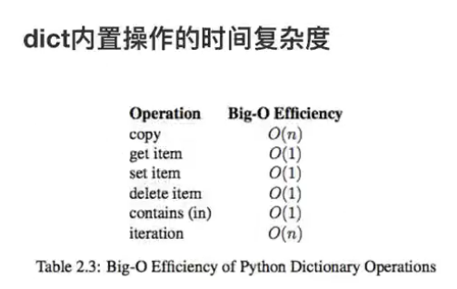

## 2. 数据结构

我们为了解决问题，需要将数据保存下来，然后根据数据的存储方式来设计算法实现进行处理，那么数据的存储方式不同就会导致需要不同的算法进行处理。我们希望算法解决问题的效率越快越好，于是我们就需要考虑数据究竟如何保存的问题，这就是数据结构。

数据是一个抽象的概念，将其进行分类后得到程序设计语言中的基本类型。如：int，float，char等。数据元素之间不是独立的，存在特定的关系，这些关系便是结构。数据结构指数据对象中数据元素之间的关系。

内置数据结构，比如列表、元组、字典。  
Python系统里面没有直接定义，需要我们自己去定义实现这些数据的组织方式，这些数据组织方式称之为Python的扩展数据结构，比如栈，队列等。

数据结构只是静态的描述了数据元素之间的关系。高效的程序需要在数据结构的基础上设计和选择算法。  
程序 = 数据结构 + 算法  
总结：算法是为了解决实际问题而设计的，数据结构是算法需要处理的问题载体

抽象数据类型(Abstract Data Type)  
抽象数据类型(ADT)的含义是指一个数学模型以及定义在此数学模型上的一组操作。即把数据类型和数据类型上的运算捆在一起，进行封装。引入抽象数据类型的目的是把数据类型的表示和数据类型上运算的实现与这些数据类型和运算在程序中的引用隔开，使它们相互独立。

最常用的数据运算有五种：  
插入  
删除  
修改  
查找  
排序

## 3. 顺序表

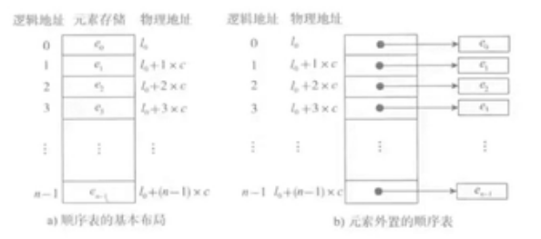

顺序表的基本形式。数据元素是连续存储，每个元素所占的存储单元大小固定相同。元素下标是逻辑地址，物理地址是通过存储区的起始地址加上逻辑地址与存储单元大小乘积计算而来。

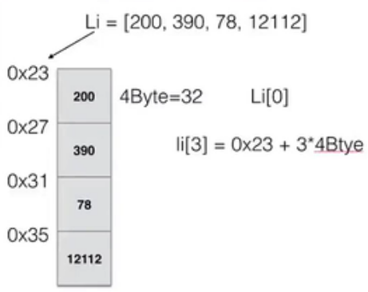

## 4. 链表

链表结构可以充分利用计算机内存空间，实现灵活的内存动态管理。

链表的定义，在每一个节点（数据存储单元）存放下一个节点的位置信息（即地址）。

顺序表和链表是线性表的两种实现模型。

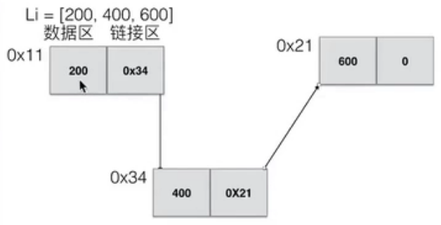

### Python 变量标识本质

```python
a = 10
b = 20
a, b = b, a
print("a %d b %d" %(a, b))
```

```
a 20 b 10
```

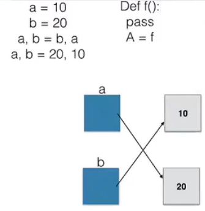

python 变量只是一个名字，代表一块内存，保存的是一个地址，地址指向代表了a的含义  
赋值并不是真正复制，而是修改引用的指向。

### 单向链表

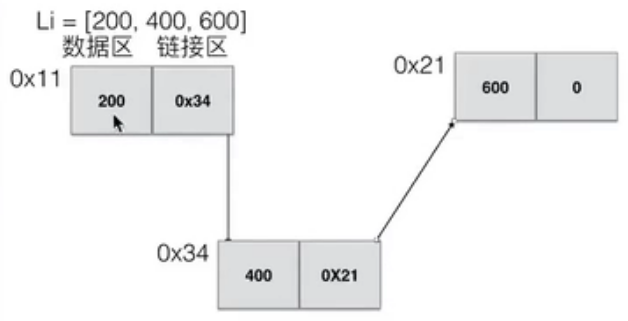

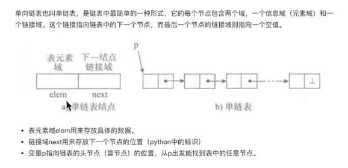

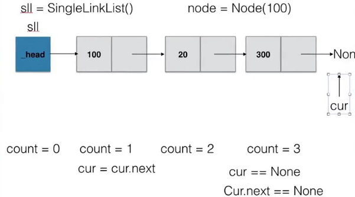

```python
# coding:utf-8

class Node(object):
    """节点类"""
    def __init__(self,elem):   # 构造函数
        self.elem = elem
        self.next = None

# node = Node(100)

class SingleLinkList(object):
    """单链表"""

    def __init__(self,node=None):   # 构造函数
        self.__head = node           # 私有属性，双下划线

    def is_empty(self):
        """链表为空"""
        return self.__head == None

    def length(self):
        """链表长度"""
        # cur游标，遍历节点
        cur = self.__head
        # count记录数量
        count = 0
        while cur != None:
            count += 1
            cur = cur.next
        return count

    def travel(self):
        """遍历整个链表"""
        # cur游标，遍历节点
        cur = self.__head
        while cur != None:
            print(cur.elem)
            cur = cur.next

    def add(self,item):
        """链表头部增加元素，头插法"""
        node = Node(item)
        node.next = self.__head
        self.__head = node

    def append(self,item):
        """链表尾部增加元素，尾插法"""
        node = Node(item)
        if self.is_empty():
            self.__head = node
        else:
            cur = self.__head
            while cur.next != None:
                cur = cur.next
            cur.next = node

    def insert(self,pos,item):
        """指定位置增加元素
        :param pos从0开始
        """
        if pos <= 0:
            self.add(item)
        elif pos > self.length()-1:
            self.append(item)
        else:
            pre = self.__head  # 找到__head指向
            count = 0
            while count < pos - 1:
                count += 1
                pre = pre.next
            # 循环退出后，pre指向pos-1位置
            node = Node(item)
            node.next = pre.next
            pre.next = node


    def remove(self,item):
        """删除节点"""
        cur = self.__head
        pre = None
        while cur != None:
            if cur.elem == item:
                # 先判断是否为头节点
                if cur == self.__head:
                    self.__head = cur.next
                else:
                    pre.next = cur.next
                break
            else:
                pre = cur   # 先移动前驱节点
                cur = cur.next

    def search(self,item):
        """查找节点是否存在"""
        cur = self.__head
        while cur != None:
            if cur.elem == item:
                return True
            else:
                cur = cur.next
        return False
```

```python
ll = SingleLinkList()  # 构造对象
print(ll.is_empty())
print(ll.length())
```

```
True
0
```

```python
ll.append(1)
print(ll.is_empty())
print(ll.length())
```

```
False
1
```

```python
ll.append(2)
ll.append(3)
ll.append(4)
ll.append(5)
ll.append(6)
ll.travel()
```

```
1
2
3
4
5
6
```

```python
ll.add(8)
ll.travel()
```

```
8
1
2
3
4
5
6
```

```python
ll.insert(-1,9)
ll.travel()
```

```
9
8
1
2
3
4
5
6
```

```python
ll.insert(2,100)
ll.travel()
```

```
9
8
100
1
2
3
4
5
6
```

```python
ll.insert(20,200)
ll.travel()
```

```
9
8
100
1
2
3
4
5
6
200
```

```python
ll.remove(100)
ll.travel()
```

```
9
8
1
2
3
4
5
6
200
```

```python
ll.remove(9)
ll.travel()
```

```
8
1
2
3
4
5
6
200
```

```python
ll.remove(200)
ll.travel()
```

```
8
1
2
3
4
5
6
```

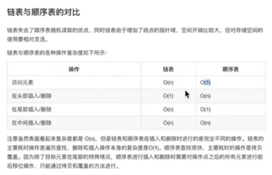

### 双向链表

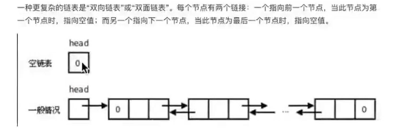

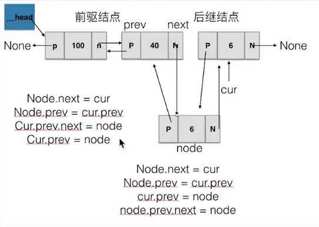

```python
# coding:utf-8
class Node():
    """节点"""
    def __init__(self,item):
        self.elem = item
        self.next = None
        self.prev = None
```

```python
class DoubleLinkList(object):
    """双链表"""

    def __init__(self,node=None):   # 构造函数
        self.__head = node           # 私有属性，双下划线

    def is_empty(self):
        """链表为空"""
        return self.__head == None

    def length(self):
        """链表长度"""
        # cur游标，遍历节点
        cur = self.__head
        # count记录数量
        count = 0
        while cur != None:
            count += 1
            cur = cur.next
        return count

    def travel(self):
        """遍历整个链表"""
        # cur游标，遍历节点
        cur = self.__head
        while cur != None:
            print(cur.elem)
            cur = cur.next

    def add(self,item):
        """链表头部增加元素，头插法"""
        node = Node(item)
        node.next = self.__head
        self.__head = node
        node.next.prev = node

        # self.__head.prev = node
        # self.__head = node

    def append(self,item):
        """链表尾部增加元素，尾插法"""
        node = Node(item)
        if self.is_empty():
            self.__head = node
        else:
            cur = self.__head
            while cur.next != None:
                cur = cur.next
            cur.next = node
            node.prev = cur

    def insert(self,pos,item):
        """指定位置增加元素
        :param pos从0开始
        """
        if pos <= 0:
            self.add(item)
        elif pos > self.length()-1:
            self.append(item)
        else:
            cur = self.__head
            count = 0
            while count < pos:
                count += 1
                cur = cur.next
            # 循环退出后，pre指向pos-1位置
            node = Node(item)
            node.next = cur
            node.prev = cur.prev
            cur.prev.next = node
            cur.prev = node


    def remove(self,item):
        """删除节点"""
        cur = self.__head
        while cur != None:
            if cur.elem == item:
                # 先判断是否为头节点
                if cur == self.__head:
                    self.__head = cur.next
                    if cur.next:
                        # 判断链表是否只有一个节点
                        cur.next.prev = None
                else:
                    cur.prev.next = cur.next
                    if cur.next:
                        cur.next.pre = cur.prev
                break
            else:
                pre = cur   # 先移动前驱节点
                cur = cur.next

    def search(self,item):
        """查找节点是否存在"""
        cur = self.__head
        while cur != None:
            if cur.elem == item:
                return True
            else:
                cur = cur.next
        return False
```

```python
ll = DoubleLinkList()  # 构造对象
print(ll.is_empty())
print(ll.length())
ll.append(1)
print(ll.is_empty())
print(ll.length())
```

```
True
0
False
1
```

```python
ll.append(2)
ll.append(3)
ll.append(4)
ll.append(5)
ll.append(6)
ll.travel()
```

```
1
2
3
4
5
6
```

```python
ll.add(8)
ll.travel()
```

```
8
1
2
3
4
5
6
```

```python
ll.insert(-1,9)
ll.travel()
ll.insert(2,100)
ll.travel()
ll.insert(20,200)
ll.travel()
```

```
9
8
1
2
3
4
5
6
9
8
100
1
2
3
4
5
6
9
8
100
1
2
3
4
5
6
200
```

```python
ll.remove(100)
ll.travel()
ll.remove(9)
ll.travel()
ll.remove(200)
ll.travel()
```

```
9
8
1
2
3
4
5
6
200
8
1
2
3
4
5
6
200
8
1
2
3
4
5
6
```

### 单向循环列表

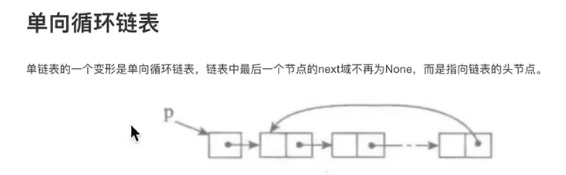

```python
# coding:utf-8

class Node(object):
    """节点类"""
    def __init__(self,elem):   # 构造函数
        self.elem = elem
        self.next = None

# node = Node(100)
```

```python
class SingleCycleList(object):
    """单向循环链表"""

    def __init__(self,node=None):   # 构造函数
        self.__head = node           # 私有属性，双下划线
        if node:
            node.next = node

    def is_empty(self):
        """链表为空"""
        return self.__head == None

    def length(self):
        """链表长度"""
        if self.is_empty():
            return 0
        # cur游标，遍历节点
        cur = self.__head
        # count记录数量
        count = 1  # 为计数
        while cur.next != self.__head:
            count += 1
            cur = cur.next
        return count

    def travel(self):
        """遍历整个链表"""
        if self.is_empty():
            return
        # cur游标，遍历节点
        cur = self.__head
        while cur.next != self.__head:
            print(cur.elem,end=" ")
            cur = cur.next
        # 退出循环，cur指向尾节点，但是节点未打印
        print(cur.elem)

    def add(self,item):
        """链表头部增加元素，头插法"""
        node = Node(item)
        if self.is_empty():
            self.__head = node
            node.next = node
        else:
            cur = self.__head
            while cur.next != self.__head:
                cur = cur.next
            # 推出循环，指向尾节点
            node.next = self.__head
            self.__head = node
            # cur.next = node
            cur.next = self.__head

    def append(self,item):
        """链表尾部增加元素，尾插法"""
        node = Node(item)
        if self.is_empty():
            self.__head = node
            node.next = node
        else:
            cur = self.__head
            while cur.next != self.__head:
                cur = cur.next
            # node.next = cur.next
            node.next = self.__head
            cur.next = node

    def insert(self,pos,item):
        """指定位置增加元素
        :param pos从0开始
        """
        if pos <= 0:
            self.add(item)
        elif pos > self.length()-1:
            self.append(item)
        else:
            pre = self.__head  # 找到__head指向
            count = 0
            while count < pos - 1:
                count += 1
                pre = pre.next
            # 循环退出后，pre指向pos-1位置
            node = Node(item)
            node.next = pre.next
            pre.next = node


    def remove(self,item):
        """删除节点"""
        if self.is_empty():
            return
        cur = self.__head
        pre = None
        while cur.next != self.__head:
            if cur.elem == item:
                # 先判断是否为头节点
                if cur == self.__head:
                    # 头节点情况，改尾节点next
                    rear = self.__head
                    while rear.next != self.__head:
                        rear = rear.next
                    self.__head = cur.next
                    rear.next = self.__head
                else:
                    pre.next = cur.next
                return
            else:
                pre = cur   # 先移动前驱节点
                cur = cur.next
        # 退出循环，指向尾节点
        if cur.elem == item:
            if cur == self.__head:
                # 链表只有一个节点
                self.__head = None
            else:
                pre.next = cur.next
                # pre.next = self.__head

    def search(self,item):
        """查找节点是否存在"""
        if self.is_empty():
            return False
        cur = self.__head
        while cur.next != self.__head:
            if cur.elem == item:
                return True
            else:
                cur = cur.next
        # 退出循环，指向尾节点
        if cur.elem == item:
            return True
        return False
```

```python
ll = SingleCycleList()  # 构造对象
print(ll.is_empty())
print(ll.length())
ll.append(1)
print(ll.is_empty())
print(ll.length())
```

```
True
0
False
1
```

```python
ll.append(2)
ll.append(3)
ll.append(4)
ll.append(5)
ll.append(6)
ll.travel()
```

```
1 2 3 4 5 6
```

```python
ll.add(8)
ll.travel()
```

```
8 1 2 3 4 5 6
```

```python
ll.insert(-1,9)
ll.travel()
ll.insert(2,100)
ll.travel()
ll.insert(20,200)
ll.travel()
```

```
9 8 1 2 3 4 5 6
9 8 100 1 2 3 4 5 6
9 8 100 1 2 3 4 5 6 200
```

```python
ll.remove(100)
ll.travel()
ll.remove(9)
ll.travel()
ll.remove(200)
ll.travel()
```

```
9 8 1 2 3 4 5 6 200
8 1 2 3 4 5 6 200
8 1 2 3 4 5 6
```

## 栈

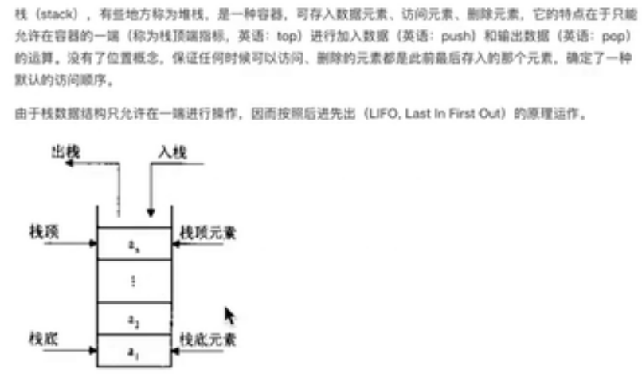

```python
class Stack(object):
    """栈"""
    def __init__(self):
        self.__list = []

    def push(self,item):
        """压栈"""
        self.__list.append(item)  # 尾部栈顶，时间复杂度低
        pass

    def pop(self):
        """出栈"""
        return self.__list.pop()
        pass

    def peek(self):
        """返回栈顶"""
        if self.__list:
            return self__list[-1]
        else:
            return None
        pass

    def is_empty(self):
        """判断空栈"""
        return self.__list == []
        # return not self.__list
        pass

    def size():
        """栈元素个数"""
        return len(self._list)
        pass

# 逻辑假
# "" 0 {} []
```

```python
s = Stack()
s.push(1)
s.push(2)
s.push(3)
s.push(4)
```

```python
print(s.pop())
print(s.pop())
print(s.pop())
print(s.pop())
```

```
4
3
2
1
```

## 队列

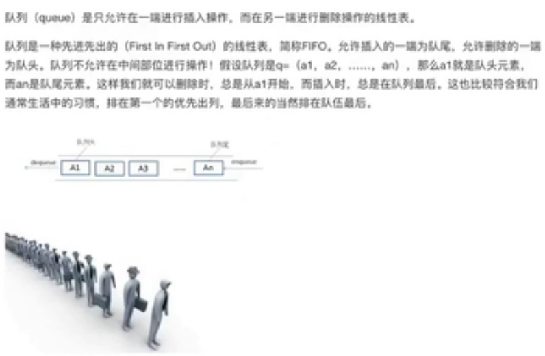

```python
class Queue(object):
    """队列"""
    def __init__(self):
        self.__list = []

    def enqueue(self,item):
        """添加元素"""
        self.__list.append(item)
        # self.__list.insert(0,item)  # O(n) 如果添加少用此
        pass

    def dequeue(self):
        """删除元素"""
        return self.__list.pop(0)    # O(n)
        # return self.__list.pop()  # O(n)
        pass

    def is_empty(self):
        """队列为空"""
        return self.__list == []
        pass

    def size(self):
        """队列大小"""
        return len(self.__list)
        pass
```

```python
s = Queue()
s.enqueue(1)
s.enqueue(2)
s.enqueue(3)
s.enqueue(4)
```

```python
print(s.dequeue())
print(s.dequeue())
print(s.dequeue())
print(s.dequeue())
```

```
1
2
3
4
```

### 双端队列

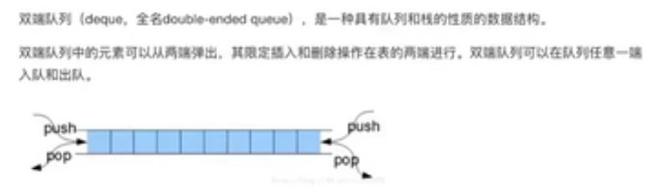

```python
class Deque(object):
    """队列"""
    def __init__(self):
        self.__list = []

    def add_front(self,item):
        """添加元素"""
        self.__list.insert(0,item)
        pass

    def add_rear(self,item):
        """添加元素"""
        self.__list.append(item)
        pass

    def pop_front(self):
        """删除元素"""
        return self.__list.pop(0)    # O(n)
        pass

    def pop_rear(self):
        """删除元素"""
        return self.__list.pop()  # O(n)
        pass

    def is_empty(self):
        """队列为空"""
        return self.__list == []
        pass

    def size(self):
        """队列大小"""
        return len(self.__list)
        pass
```

```python
s = Deque()
s.add_front(1)
s.add_front(2)
s.add_rear(3)
s.add_rear(4)

# 2134
```

```python
print(s.size())
```

```
4
```

```python
print(s.pop_front())
print(s.pop_front())
print(s.pop_rear())
print(s.pop_rear())
```

```
2
1
4
3
```

## 5.排序与搜索

排序算法（英语：Sorting algorithm）是一种能将一串数据依照特定顺序进行排列的一种算法。

排序算法的稳定性  
稳定性：稳定排序算法会让原本有相等键值的纪录维持相对次序。也就是如果一个排序算法是稳定的，当有两个相等键值的纪录R和S，且在原本的列表中R出现在S之前，在排序过的列表中R也将会是在S之前。

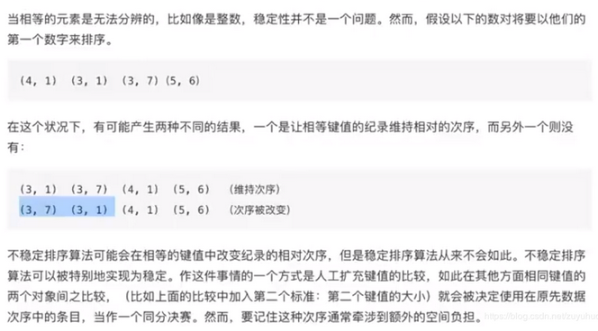

### 冒泡排序

冒泡排序（英语：Bubble Sort）是一种简单的排序算法。它重复地遍历要排序的数列，一次比较两个元素，如果他们的顺序错误就把他们交换过来。遍历数列的工作是重复地进行直到没有再需要交换，也就是说该数列已经排序完成。这个算法的名字由来是因为越小的元素会经由交换慢慢“浮”到数列的顶端。

冒泡排序算法的运作如下：

```
比较相邻的元素。如果第一个比第二个大（升序），就交换他们两个。
对每一对相邻元素作同样的工作，从开始第一对到结尾的最后一对。这步做完后，最后的元素会是最大的数。
针对所有的元素重复以上的步骤，除了最后一个。
持续每次对越来越少的元素重复上面的步骤，直到没有任何一对数字需要比较。
```

时间复杂度

```
最优时间复杂度：O(n) （表示遍历一次发现没有任何可以交换的元素，排序结束。）
最坏时间复杂度：O(n^2)
稳定性：稳定
```

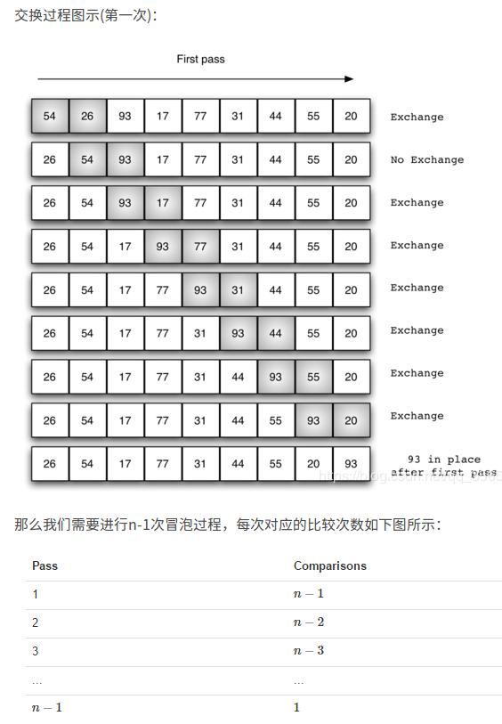

```python
def bubble_sort(alist):
    """冒泡排序"""
    n = len(alist)
    for j in range(n-1):   # 冒泡次数
        "j表示每次遍历需要比较的次数，是递减的"
        for i in range(0, n-1-j):  # 从头到尾几步
            if alist[i]>alist[i+1]:
                alist[i],alist[i+1]=alist[i+1],alist[i]
```

```python
li=[54,26,93,17,77,31,44,55,20]
bubble_sort(li)
print(li)
```

```
[17, 20, 26, 31, 44, 54, 55, 77, 93]
```

```python
def bubble_sort1(alist):
    """冒泡排序"""
    n = len(alist)
    for j in range(n-1, 0, -1):   # 冒泡次数
        "j表示每次遍历需要比较的次数，是递减的"
        for i in range(j):  # 从头到尾几步
            if alist[i]>alist[i+1]:
                alist[i],alist[i+1]=alist[i+1],alist[i]
```

```python
li1=[54,26,93,17,77,31,44,55,20]
bubble_sort1(li1)
print(li1)
```

```
[17, 20, 26, 31, 44, 54, 55, 77, 93]
```

```python
def bubble_sort_count(alist):
    """冒泡排序"""
    n = len(alist)
    for j in range(n-1, 0, -1):   # 冒泡次数
        "j表示每次遍历需要比较的次数，是递减的"
        count = 0
        for i in range(j):  # 从头到尾几步
            if alist[i]>alist[i+1]:
                alist[i],alist[i+1]=alist[i+1],alist[i]
                count += 1
        if count == 0: # 不需要交换即已排序
            return
```

```python
li1=[54,26,93,17,77,31,44,55,20]
bubble_sort_count(li1)
print(li1)
```

```
[17, 20, 26, 31, 44, 54, 55, 77, 93]
```

### 选择排序

选择排序（Selection sort）是一种简单直观的排序算法。它的工作原理如下。首先在未排序序列中找到最小（大）元素，存放到排序序列的起始位置，然后，再从剩余未排序元素中继续寻找最小（大）元素，然后放到已排序序列的末尾。以此类推，直到所有元素均排序完毕。

选择排序的主要优点与数据移动有关。如果某个元素位于正确的最终位置上，则它不会被移动。选择排序每次交换一对元素，它们当中至少有一个将被移到其最终位置上，因此对n个元素的表进行排序总共进行至多n-1次交换。在所有的完全依靠交换去移动元素的排序方法中，选择排序属于非常好的一种。

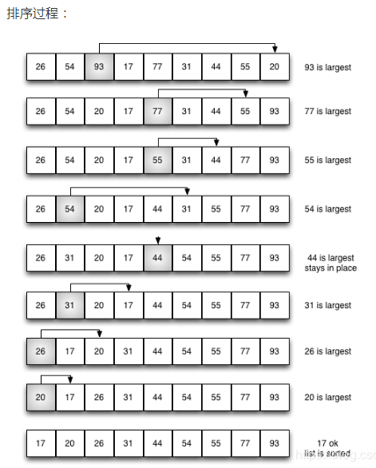

时间复杂度  
最优时间复杂度：O(n^2)  
最坏时间复杂度：O(n^2)  
稳定性：不稳定（考虑升序每次选择最大的情况）

```python
def selection_sort(alist):
    """选择排序"""
    n = len(alist)
    # 需要进行n-1次选择操作  0 - n-2
    for i in range(n-1):
        # 记录最小位置
        min_index = i
        # 从i+1位置到末尾选择出最小数据
        for j in range(i+1, n):
            if alist[j] < alist[min_index]:
                min_index = j
        # 如果选择出的数据不在正确位置，进行交换
        if min_index != i:
            alist[i], alist[min_index] = alist[min_index], alist[i]
```

```python
li=[54,26,93,17,77,31,44,55,20]
selection_sort(li)
print(li)
```

```
[17, 20, 26, 31, 44, 54, 55, 77, 93]
```

### 插入排序

插入排序（Insertion Sort）是一种简单直观的排序算法。它的工作原理是构建已排序序列，将未排序元素找到已排序序列的相应位置并插入。插入排序在实现上，需要反复把已排序元素逐步向后挪位，为最新元素提供插入空间。 插入排序算法的具体运作如下：

```
将第一个元素视为已排序序列，比较第一个元素与第二个元素，若第二个元素小于第一个元素，则交换。
将前两个元素视为已排序序列，比较第三个元素与第二个元素，若第三个元素小于第二个元素，则交换；比较交换后的第二个元素与第一个元素，若第二个元素小于第一个元素，则交换。
将前三个元素视为已排序序列，重复以上步骤。
```

最优时间复杂度：O(n) （升序排列，序列已经处于升序状态）  
最坏时间复杂度：O(n^2)  
稳定性：稳定

```python
def insert_sort(alist): # 从第二个位置，即下标为1的元素开始向前插入
    for j in range(1, len(alist)):
        # 从第i个元素开始向前比较，如果小于前一个元素，交换位置
        for i in range(j, 0, -1):
            if ali[i] < ali[i - 1]:
                ali[i], ali[i - 1] = ali[i - 1], ali[i]
```

```python
ali = [54, 26, 93, 22, 77, 31, 44, 55, 20]
print(ali)
insert_sort(ali)
print(ali)
```

```
[54, 26, 93, 22, 77, 31, 44, 55, 20]
[20, 22, 26, 31, 44, 54, 55, 77, 93]
```

```python
def insert_sort1(ali):
    n = len(ali)
    for j in range(1, n):  # 1 - n-1
        i = j
        # i 代表内层循环起始，从右无序中取元素，插入到有序位置中
        while i > 0:
            if ali[i] < ali[i - 1]:
                ali[i], ali[i - 1] = ali[i - 1], ali[i]
                i -= 1
            else:  # 最优时间复杂度
                break
```

```python
alist = [54,26,93,17,77,31,44,55,20]
print(alist)
insert_sort1(alist)
print(alist)
```

```
[54, 26, 93, 17, 77, 31, 44, 55, 20]
[17, 20, 26, 31, 44, 54, 55, 77, 93]
```

### 希尔排序

基本思想：希尔排序(Shell Sort)是插入排序的一种。也称缩小增量排序，是直接插入排序算法的一种更高效的改进版本。希尔排序是非稳定排序算法。该方法因DL．Shell于1959年提出而得名。 希尔排序是把记录按下标的一定增量分组，对每组使用直接插入排序算法排序；随着增量逐渐减少，每组包含的关键词越来越多，当增量减至1时，整个文件恰被分成一组，算法便终止。

希尔排序算法的具体运作如下：

```
将数列按照一定步长进行分割，得到多组数列，对每一组数列进行插入排序。
减小步长，重复以上步骤。
直到步长为1，整个数列被分为一组，排序完成。
```

图解：

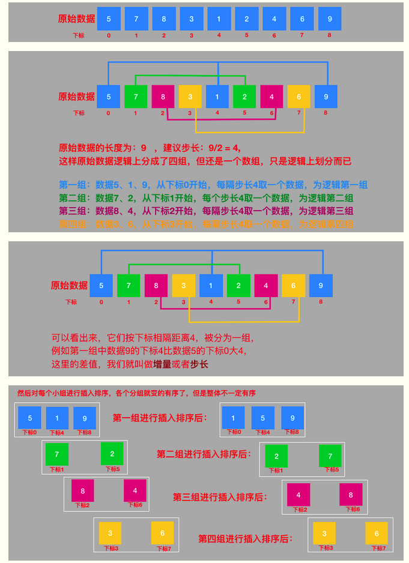

例如，假设有这样一组数[ 13 14 94 33 82 25 59 94 65 23 45 27 73 25 39 10 ]，如果我们以步长为5开始进行排序，我们可以通过将这列表放在有5列的表中来更好地描述算法，这样他们就应该看起来是这样(竖着的元素是步长组成)：

13 14 94 33 82  
25 59 94 65 23  
45 27 73 25 39  
10

我们对每一列都进项排序

10 14 73 25 23  
13 27 94 33 39  
25 59 94 65 82  
45

将上述四行数字，依序接在一起时我们得到：[ 10 14 73 25 23 13 27 94 33 39 25 59 94 65 82 45 ]。这时10已经移至正确位置了，然后再以3为步长进行排序：

10 14 73  
25 23 13  
27 94 33  
39 25 59  
94 65 82  
45

排序之后变为 10 14 13  
25 23 33  
27 25 59  
39 65 73  
45 94 82  
94

我们再将这几列数按照顺序拼接在一起，最后按照步长为1来进行排序（这一步可以看成是将一列已经具有一定规律的数进行了一遍插入排序）最后的到结果。

对于希尔排序，我们所选定的步长（用gap表示）并不是固定的，对于一列数字我们可以人为的定义一个gap（通常用数组的长度来除某个值得到步长（例：数组长度为n=12 gap=n//2=6）），此时用步长gap进行第一次排序，第二次排序时我们可以用gap减去或除某个数值来得到新的gap（接上诉例子：gap=6//2=3），以此类推：当有余数时我们可以对其进行取整，直到最后我们进行了一遍gap为1的排序，然后得到了排序后的结果，希尔排序就完成了。

时间复杂度  
最优时间复杂度：根据步长序列的不同而不同  
最坏时间复杂度：O(n^2)  
稳定想：不稳定

```python
 def shell_sort(ali):
        n = len(ali)
        gap = n // 2 # 初始步长
        while gap > 0:
            # 按步长进行插入排序
            for j in range(gap, n):
                # j = gap, gap+1, ...
                i = j # 插入排序
                while i > 0:
                    if ali[i] < ali[i - gap]:
                        ali[i], ali[i - gap] = ali[i - gap], ali[i]
                        i -= gap
                    else:
                        break
            gap //= 2 # 得到新的步长
```

```python
alist = [54,26,93,17,77,31,44,55,20]
print(alist)
shell_sort(alist)
print(alist)
```

```
[54, 26, 93, 17, 77, 31, 44, 55, 20]
[17, 20, 26, 31, 44, 54, 55, 77, 93]
```

### 快速排序 （必考）

快速排序又称为划分交换排序（partition-exchange sort），通过一趟排序将要排序的数据分割成独立的两部分，其中一部分的所有数据都比另外一部分的所有数据都要小，然后再按此方法对这两部分数据分别进行快速排序，整个排序过程可以递归进行，以此达到整个数据变成有序序列。

具体实现步骤：

从数列中挑出一个元素，称为"基准"（pivot）。  
重新排序数列，所有元素比基准值小的摆放在基准前面，所有元素比基准值大的摆在基准的后面（相同的数可以到任一边）。在这个分区结束之后，该基准就处于数列的中间位置。这个称为分区（partition）操作。  
递归地（recursive）把小于基准值元素的子数列和大于基准值元素的子数列排序。

时间复杂度分析：

```
最优时间复杂度：O(nlogn)
最坏时间复杂度：O(n^2) （恰好每次只分给某一边一个数）
稳定性：不稳定
```

2 *2* 2 ... = n。 分割次数是logn，对每次分割结果排序复杂度是n

```python
def quick_sort1(alist,first,last):
    '''快速排序(升序)'''
    if first >= last:
        return
    mid_value = alist[first]
    low = first #注意low和high是下标。
    high = last
    while low<high:
        #让high游标向左移动
        #这个等号表示把相等的情况放在high这边
        while low < high and alist[high]>=mid_value:
            high-=1
        alist[low] = alist[high]
            #让low游标向右移动
        while low < high and alist[low]<mid_value:
                low+=1
        alist[high] = alist[low]
    alist[low] = mid_value
    quick_sort1(alist,first,low-1)
    #递归作用在alist上
    quick_sort1(alist,low+1,last)
```

```python
def quick_sort(alist, start, end):
    """快速排序"""
    # 递归终止条件
    if start >= end:
        return
    # n = len(alist)
    mid_value = alist[start]
    #low = 0
    #high = n - 1
    low = start
    high = end
    while low < high:
        # high游标左移
        while low < high and alist[high] >=  mid_value: # 等于情况在一边
                high -= 1
        alist[low] = alist[high]

        # low 游标右移
        while low < high and alist[low] < mid_value:
            low += 1
        alist[high] = alist[low]

    # 从循环退出时low=high
    alist[low] = mid_value

    # 对low左边快排
    quick_sort(alist,start,low-1)   # alist[:low-1]是新列表
    # 对low右边快排
    quick_sort(alist,low+1,end)
```

```python
alist = [54,26,93,17,77,31,44,55,20]
print(alist)
quick_sort(alist,0,len(alist)-1)
print(alist)
```

```
[54, 26, 93, 17, 77, 31, 44, 55, 20]
[17, 20, 26, 31, 44, 54, 55, 77, 93]
```

### 归并排序

归并排序是采用分治法的一个非常典型的应用。归并排序的思想就是先递归分解数组，再合并数组。得到新列表，有额外内存开销。

将数组分解最小之后，然后合并两个有序数组，基本思路是比较两个数组的最前面的数，谁小就先取谁，取了后相应的指针就往后移一位。然后再比较，直至一个数组为空，最后把另一个数组的剩余部分复制过来即可。

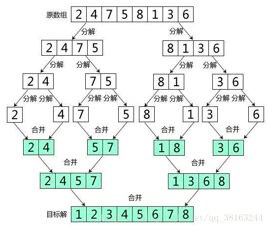

时间复杂度：  
最优时间复杂度：O(nlogn) 每一级时间复杂度是O(n),执行了logn次  
最坏时间复杂度：O(nlogn)  
稳定性：稳定

```python
def merge(left, right):
    '''合并操作，将两个有序数组left[]和right[]合并成一个大的有序数组'''
    #left与right的下标指针
    left_pointer, right_pointer = 0, 0
    result = []
    while left_pointer<len(left) and right_pointer<len(right):
        if left[left_pointer] < right[right_pointer]:
            result.append(left[left_pointer])
            left_pointer += 1
        else:
            result.append(right[right_pointer])
            right_pointer += 1
    result += left[left_pointer:]
    result += right[right_pointer:]
    return result

def merge_sort(alist):
    """归并排序"""
    n = len(alist)
    if n <= 1:
        return alist
    # 二分分解
    mid = n // 2
    # left 采用归并排序后的新列表，递归
    left = merge_sort(alist[:mid])
    # right 采用归并排序后的新列表，递归
    right = merge_sort(alist[mid:])
    # 合并
    return merge(left,right)
```

```python
alist = [54,26,93,17,77,31,44,55,20]
sorted_alist = merge_sort(alist)
print(alist)
print(sorted_alist)
```

```
[54, 26, 93, 17, 77, 31, 44, 55, 20]
[17, 20, 26, 31, 44, 54, 55, 77, 93]
```

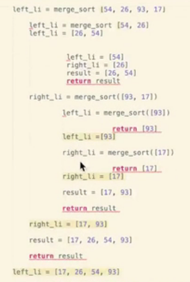

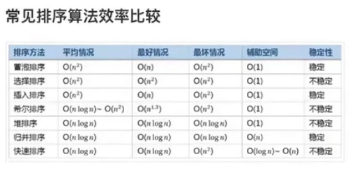

### 搜索

搜索是在一个项目集合中找到一个特定项目的算法过程。搜索通常的答案是真的或假的，因为该项目是否存在。 搜索的几种常见方法：顺序查找、二分法查找、二叉树查找、哈希查找

### 二分法查找

二分查找又称折半查找，优点是比较次数少，查找速度快，平均性能好；其缺点是要求待查表为有序表，且插入删除困难。因此，折半查找方法适用于不经常变动而查找频繁的有序列表。首先，假设表中元素是按升序排列，将表中间位置记录的关键字与查找关键字比较，如果两者相等，则查找成功；否则利用中间位置记录将表分成前、后两个子表，如果中间位置记录的关键字大于查找关键字，则进一步查找前一子表，否则进一步查找后一子表。重复以上过程，直到找到满足条件的记录，使查找成功，或直到子表不存在为止，此时查找不成功。

时间复杂度分析：

```
最优时间复杂度：O(1)
最坏时间复杂度：O(logn)
```

```python
def binary_search(alist,item):
    '''二分查找（非递归版本）'''
    '''alist(是升序)'''
    n = len(alist)
    first = 0
    last = n - 1
    while first <= last:
        mid = (first+last)//2
        if alist[mid] == item:
            return True
        elif item < alist[mid]:
            last = mid - 1
        else:
            first = mid + 1
    return False
```

```python
def binary_search_recur(alist,item):
    '''二分查找（递归版本）'''
    '''alist(是升序)'''
    n = len(alist)
    if n > 0:
        mid = n // 2
        if alist[mid] == item:
            return True
        elif item < alist[mid]:
            return binary_search_recur(alist[:mid],item)
        else:
            return binary_search_recur(alist[mid+1:],item)
    return False
```

```python
li = [17, 20, 26, 31, 44, 54, 55, 77, 93]
print(binary_search_recur(li,55))
print(binary_search_recur(li,100))
```

```
True
False
```

```python
li = [17, 20, 26, 31, 44, 54, 55, 77, 93]
print(binary_search(li,55))
print(binary_search(li,100))
```

```
True
False
```

## 树

**树的概念**

树（英语：tree）是一种抽象数据类型（ADT）或是实作这种抽象数据类型的数据结构，用来模拟具有树状结构性质的数据集合。它是由n（n>=1）个有限节点组成一个具有层次关系的集合。把它叫做“树”是因为它看起来像一棵倒挂的树，也就是说它是根朝上，而叶朝下的。它具有以下的特点：

```
每个节点有零个或多个子节点；
没有父节点的节点称为根节点；
每一个非根节点有且只有一个父节点；
除了根节点外，每个子节点可以分为多个不相交的子树。
```

**树的术语**

```
节点的度：一个节点含有的子树的个数称为该节点的度；
树的度：一棵树中，最大的节点的度称为树的度；
叶节点或终端节点：度为零的节点；
父亲节点或父节点：若一个节点含有子节点，则这个节点称为其子节点的父节点；
孩子节点或子节点：一个节点含有的子树的根节点称为该节点的子节点；
兄弟节点：具有相同父节点的节点互称为兄弟节点；
节点的层次：从根开始定义起，根为第1层，根的子节点为第2层，以此类推；
树的高度或深度：树中节点的最大层次；
堂兄弟节点：父节点在同一层的节点互为堂兄弟；
节点的祖先：从根到该节点所经分支上的所有节点；
子孙：以某节点为根的子树中任一节点都称为该节点的子孙。
森林：由m（m>=0）棵互不相交的树的集合称为森林。
```

**树的种类**

```
无序树：树中任意节点的子节点之间没有顺序关系，这种树称为无序树，也称为自由树；

有序树：树中任意节点的子节点之间有顺序关系，这种树称为有序树；

    二叉树：每个节点最多含有两个子树的树称为二叉树；
        完全二叉树：对于一颗二叉树，假设其深度为d(d>1)。除了第d层外，其它各层的节点数目均已达最大值，且第d层所有节点从左向右连续地紧密排列，这样的二叉树被称为完全二叉树，其中满二叉树的定义是所有叶节点都在最底层的完全二叉树;
        平衡二叉树（AVL树）：当且仅当任何节点的两棵子树的高度差不大于1的二叉树；
        排序二叉树（二叉查找树（英语：Binary Search Tree），也称二叉搜索树、有序二叉树）；

    霍夫曼树（用于信息编码）：带权路径最短的二叉树称为哈夫曼树或最优二叉树；
    B树：一种对读写操作进行优化的自平衡的二叉查找树，能够保持数据有序，拥有多余两个子树。
```

**树的存储**

顺序存储：将数据结构存储在固定的数组中，然在遍历速度上有一定的优势，但因所占空间比较大，是非主流二叉树。二叉树通常以链式存储。

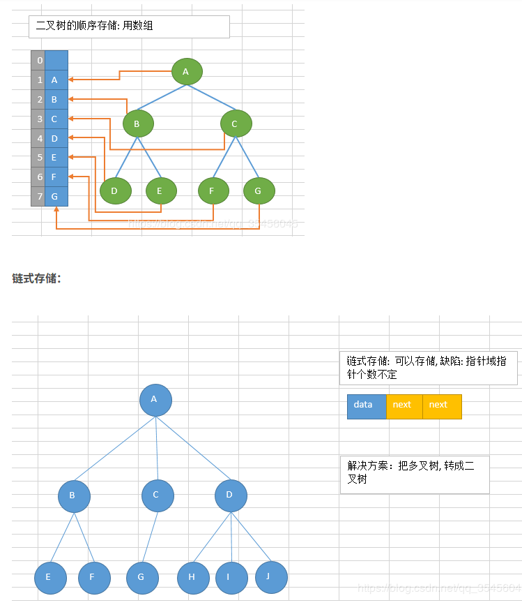

常见的一些树的应用场景

1.xml，html等，那么编写这些东西的解析器的时候，不可避免用到树  
2.路由协议就是使用了树的算法  
3.mysql数据库索引  
4.文件系统的目录结构  
5.所以很多经典的AI算法其实都是树搜索，此外机器学习中的decision tree也是树结构

### 二叉树

二叉树的基本概念

```
  二叉树是每个节点最多有两个子树的树结构。通常子树被称作“左子树”（left subtree）和“右子树”（right subtree）
```

二叉树的性质（特性）

性质1：在二叉树的第i层上至多有2(i−1)个结点（i>0）  
性质2：深度为k的二叉树至多有2^k−1个结点（k>0）  
性质3：对于任意一棵二叉树，如果其叶结点树为N0，而度数为2的结点总数为N2，则N0=N2+1  
性质4：具有n个结点的完全二叉树的深度必为log2(n+1)  
性质5：具有n个结点的完全二叉树，若从上至下、从左至右编号，则编号为i的结点，其做孩子编号必为2i，其右孩子编号必为2i+1；其双亲的编号必为i/2（i=1时为根，除外）

```python
class Node(object):
    """二叉树的结点"""
    def __init__(self,elem):
        self.elem = elem
        self.lchild = None
        self.rchild = None
```

```python
class Tree(object):
    """二叉树"""
    def __init__(self):
        self.root = None

    def add(self, item):
        node = Node(item)
        if self.root is None:
            self.root = node
            return
        queue=[]
        queue.append(self.root)
        while queue:
            cur_node = queue.pop(0)
            if cur_node.lchild is None:
                cur_node.lchild = node
                return
            else:
                queue.append(cur_node.lchild)
            if cur_node.rchild is None:
                cur_node.rchild = node
                return
            else:
                queue.append(cur_node.rchild)
    def breadth_travel(self):
        """广度遍历"""
        if self.root == None:
            return
        queue = []
        queue.append(self.root)
        while queue:
            node = queue.pop(0)
            print(node.elem)
            if node.lchild != None:
                queue.append(node.lchild)
            if node.rchild != None:
                queue.append(node.rchild)

    def preorder(self, node):
        """递归实现先序遍历"""
        if node == None:
            return
        print(node.elem, end=" ")
        self.preorder(node.lchild)
        self.preorder(node.rchild)

    def inorder(self, node):
        """递归实现中序遍历"""
        if node == None:
            return
        self.inorder(node.lchild)
        print(node.elem, end=" ")
        self.inorder(node.rchild)

    def postorder(self, node):
        """递归实现后序遍历"""
        if node == None:
            return
        self.postorder(node.lchild)
        self.postorder(node.rchild)
        print(node.elem, end=" ")
```

```python
bool([None])
```

```
True
```

```python
bool([])
```

```
False
```

```python
tree = Tree()
```

```python
# def breadth_travel(self, root):
#     """广度遍历"""
#     if self.root == None:
#         return
#     queue = []
#     queue.append(self.root)
#     while queue:
#         node = queue.pop(0)
#         print(node.elem)
#         if node.lchild != None:
#             queue.append(node.lchild)
#         if node.rchild != None:
#             queue.append(node.rchild)
```

```python
tree = Tree()
tree.add(0)
tree.add(1)
tree.add(2)
tree.add(3)
tree.add(4)
tree.add(5)
tree.add(6)
tree.add(7)
tree.add(8)
tree.add(9)
tree.breadth_travel()
print(" ")
tree.preorder(tree.root)
```

```
0
1
2
3
4
5
6
7
8
9

0 1 3 7 8 4 9 2 5 6
```

```python
tree.inorder(tree.root)
```

```
7 3 8 1 9 4 0 5 2 6
```

```python
tree.postorder(tree.root)
```

```
7 8 3 9 4 1 5 6 2 0
```

先序遍历：根-左-右

中序遍历：左-根-右

后序遍历：左-右-根

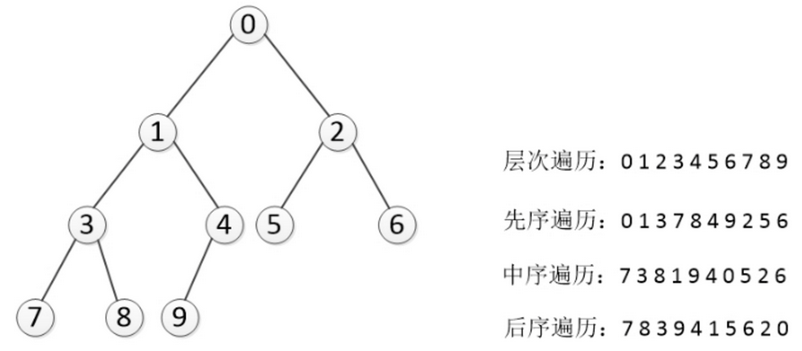

### 由遍历确定一棵树

需要两个，至少包含中序遍历就可以写出来，可以将左右分开

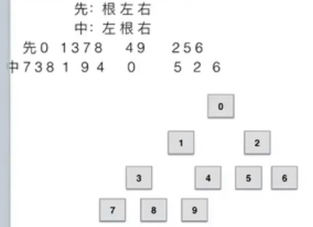

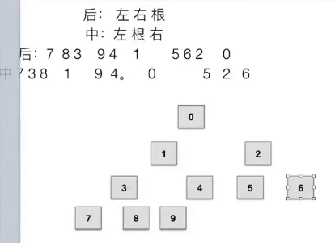